# Librería GGPLOT2

Edurne Alonso

2020-11-20 10:13:48

# 1.- Introducción

La librería GGPLOT es un paquete de visualización de datos para el lenguaje de programación R que implementa lo que se conoce como la “Gramática de los Gráficos”, es decir, una representación esquemática y en capas de lo que se dibuja en dichos gráficos como, por ejemplo:

- Tipo de gráfico que se utiliza (geoms – función que representa los puntos)
- Temas del gráfico
- Marcos y los ejes
- Textos
- Leyendas
- Títulos
- Colores
- Símbolos
- Tamaños

Cada ggplot2 tiene 3 componentes mínimas necesarias para poder realizar un gráfico:

1. Los datos
2. Un conjunto de asignaciones estéticas entre las variables de los datos y las propiedades visuales
3. Al menos una capa que describe cómo representar cada observación. Las capas se crean generalmente con una función geom_x()

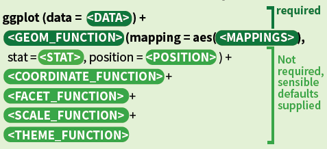

El siguiente libro tiene una versión online bastante completa: https://ggplot2-book.org/

# 2.- Librerías y datos

Se cargan las librerías necesarias para poder ejecutar el código de la sesión.

```r
# install.packages("ggplot2", "patchwork")
library(ggplot2)
library(patchwork)
```

Además, se va a utilizar el conjunto **mpg** propio de R y de la librería ggplot2 que incluye las siguientes variables:

- manufacturer: Fabricante
- model: Modelo de coche. Son 38 modelos
- displ: Cilindrada del motor en litros
- year: Año de fabricación
- cyl: Número de cilindrad
- trans: Tipo de transmisión
- drv: Tracción del motor
  - rueda delantera (f)
  - rueda trasera (r)
  - cuatro ruedas (4)
- cty: Millas por galón (mpg) para conducción en ciudad
- hwy: Millas por galón (mpg) para conducción en carretera
- fl: Tipo de fuel
- class: Variable categórica que describe el “tipo” de coche: biplaza, SUV, compacto, etc.

Obtenemos una muestra de los datos y los estadísticos básicos (máximo, mínimo, promedio, cuartiles y si hubiese valores perdidos) de este conjunto.

```r
head(mpg)
```

```
## # A tibble: 6 x 11
##   manufacturer model displ  year   cyl trans      drv     cty   hwy fl    class
##   <chr>        <chr> <dbl> <int> <int> <chr>      <chr> <int> <int> <chr> <chr>
## 1 audi         a4      1.8  1999     4 auto(l5)   f        18    29 p     compa~
## 2 audi         a4      1.8  1999     4 manual(m5) f        21    29 p     compa~
## 3 audi         a4      2    2008     4 manual(m6) f        20    31 p     compa~
## 4 audi         a4      2    2008     4 auto(av)   f        21    30 p     compa~
## 5 audi         a4      2.8  1999     6 auto(l5)   f        16    26 p     compa~
## 6 audi         a4      2.8  1999     6 manual(m5) f        18    26 p     compa~
```

```r
summary(mpg)
```

```
##  manufacturer          model               displ            year
##  Length:234         Length:234         Min.   :1.600   Min.   :1999
##  Class :character   Class :character   1st Qu.:2.400   1st Qu.:1999
##  Mode  :character   Mode  :character   Median :3.300   Median :2004
##                                        Mean   :3.472   Mean   :2004
##                                        3rd Qu.:4.600   3rd Qu.:2008
##                                        Max.   :7.000   Max.   :2008
##       cyl           trans               drv                 cty
##  Min.   :4.000   Length:234         Length:234         Min.   : 9.00
##  1st Qu.:4.000   Class :character   Class :character   1st Qu.:14.00
##  Median :6.000   Mode  :character   Mode  :character   Median :17.00
##  Mean   :5.889                                         Mean   :16.86
##  3rd Qu.:8.000                                         3rd Qu.:19.00
##  Max.   :8.000                                         Max.   :35.00
##       hwy             fl               class
##  Min.   :12.00   Length:234         Length:234
##  1st Qu.:18.00   Class :character   Class :character
##  Median :24.00   Mode  :character   Mode  :character
##  Mean   :23.44
##  3rd Qu.:27.00
##  Max.   :44.00
```

# 3.- Parámetros requeridos

Supongamos que queremos representar **cuántos modelos tiene cada fabricante** en el dataset. Para ello, le pasamos el dataset y la variable a graficar a la función ggplot(). Después, seleccionamos el parámetro geom_x() para establecer el tipo de gráfico. Utilizamos el gráfico de barras para reprensentar una variable categórica: geom_bar().

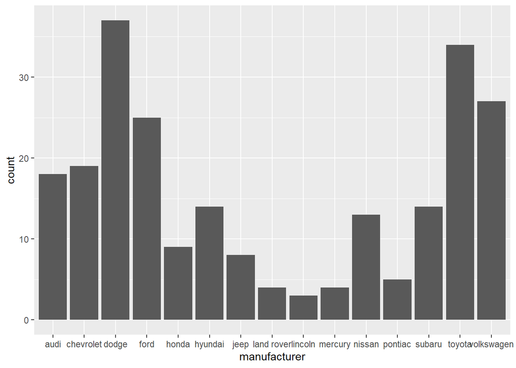

```r
ggplot(mpg, aes(manufacturer)) +
  geom_bar()
```

Se observa que *Dodge* y *Toyota* son los que más modelos tienen.

# 4.- Parámetros opcionales

## 4.1.- ggtitle(), xlab() e ylab()

Ahora, vamos a mejorar el aspecto del gráfico cambiando su color y etiquetas. Para poder cambiar el color del gráfico introducimos el parámetro *‘fill’* en la función geom_bar(). Este parámetro nos permite rellenar el color de las barras a nuestro gusto. R cuenta con una extensa gama de colores.

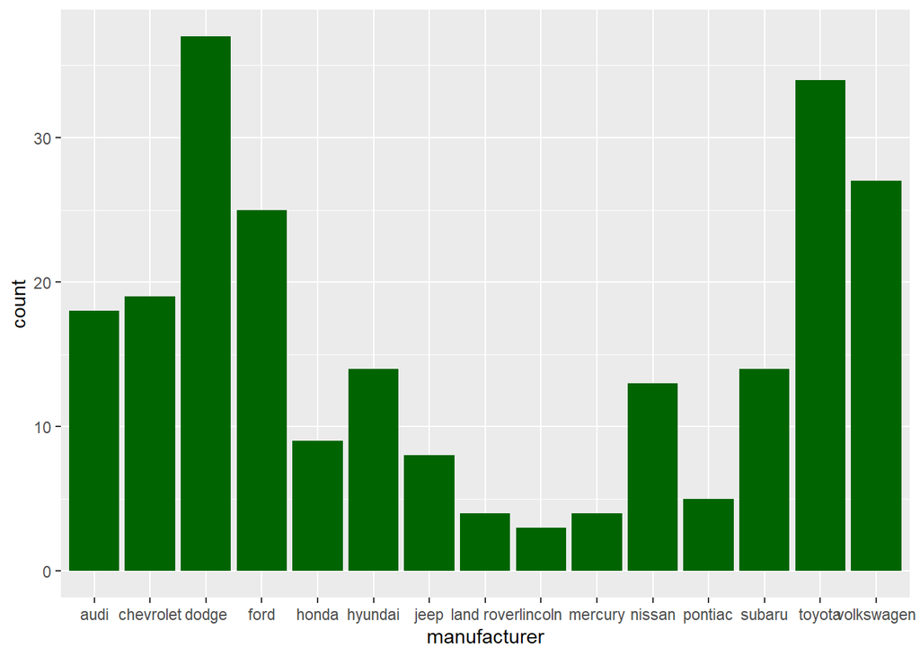

```r
ggplot(mpg, aes(manufacturer)) +
  geom_bar(fill = "darkgreen")
```

Ahora, para añadir un título al gráfico utilizaremos la función ggtitle() y cambiaremos los nombres de los ejes con xlab() e ylab():

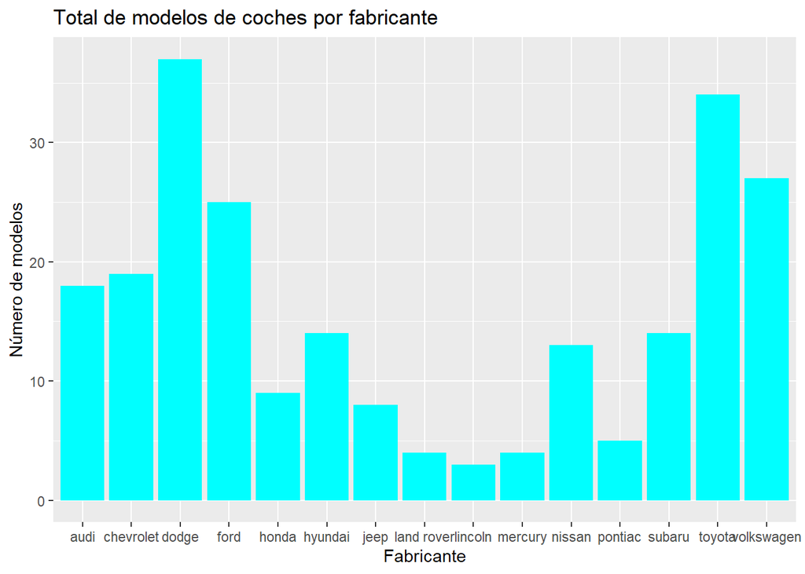

```r
ggplot(mpg, aes(manufacturer)) +
  geom_bar(fill = "cyan1") +
  ggtitle("Total de modelos de coches por fabricante") +
  xlab("Fabricante") +
  ylab("Número de modelos")
```

Supongamos, ahora, que queremos ver la distribución de las **Millas por galón (mpg) para la conducción en carretera**. Para ello, utilizamos el histograma, geom_histogram(). Además, mejoramos el aspecto del gráfico cambiando sus colores, etiquetas y añadiremos un título.

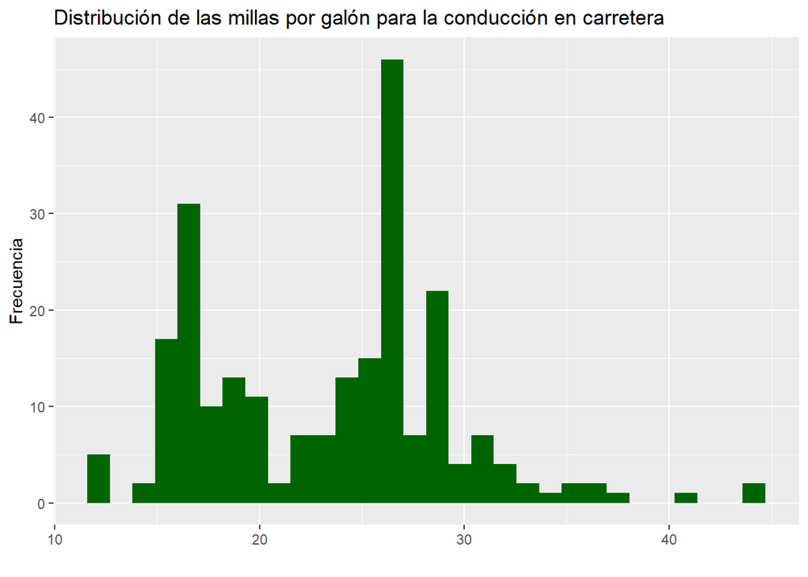

```r
ggplot(mpg, aes(hwy)) +
  geom_histogram(fill = "darkgreen") +
  ggtitle("Distribución de las millas por galón para la conducción en carretera") +
  xlab("") +
  ylab("Frecuencia")
```

Es interesante conocer que se pueden ajustar los bins o la anchura de los bins. Los bins se refiere al número de barras del gráfico las cuales son equidistantes a lo largo del eje x entre los valores mínimo y máximo de la variable a representar. Para ello, añadimos el parámetro ‘bins’ a la función geom_histogram().

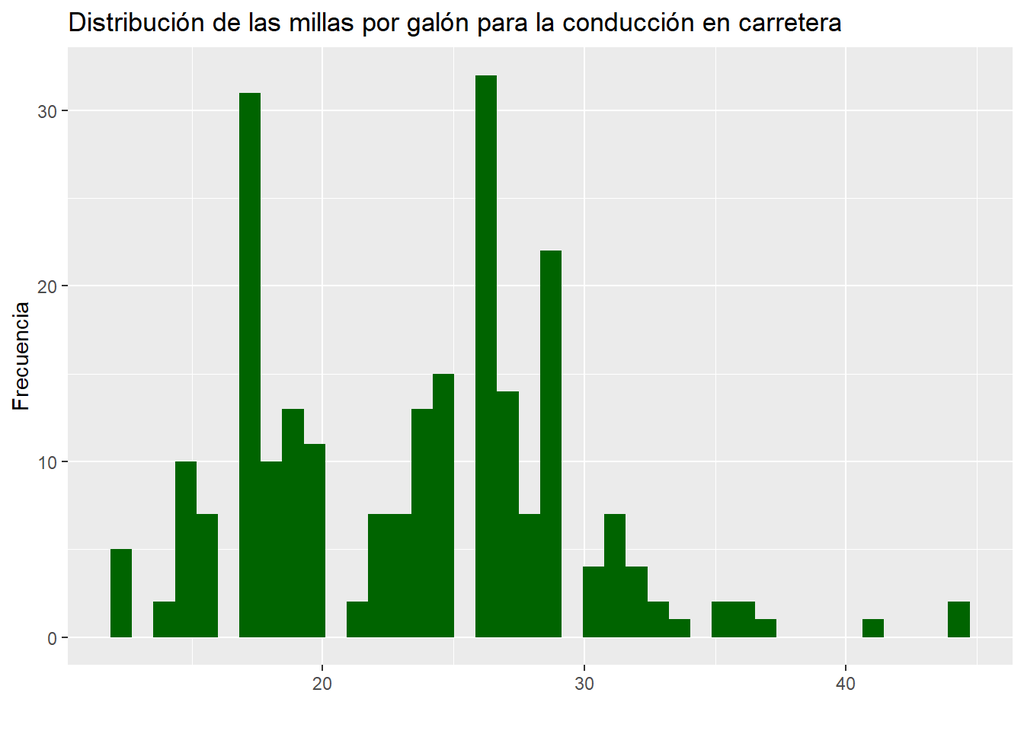

```r
ggplot(mpg, aes(hwy)) +
  geom_histogram(fill = "darkgreen", bins = 40) +
  ggtitle("Distribución de las millas por galón para la conducción en carretera") +
  xlab("") +
  ylab("Frecuencia")
```

Si queremos manipular la anchura de las barras, añadimos el parámetro ‘binwidth’ a la función geom_histogram()

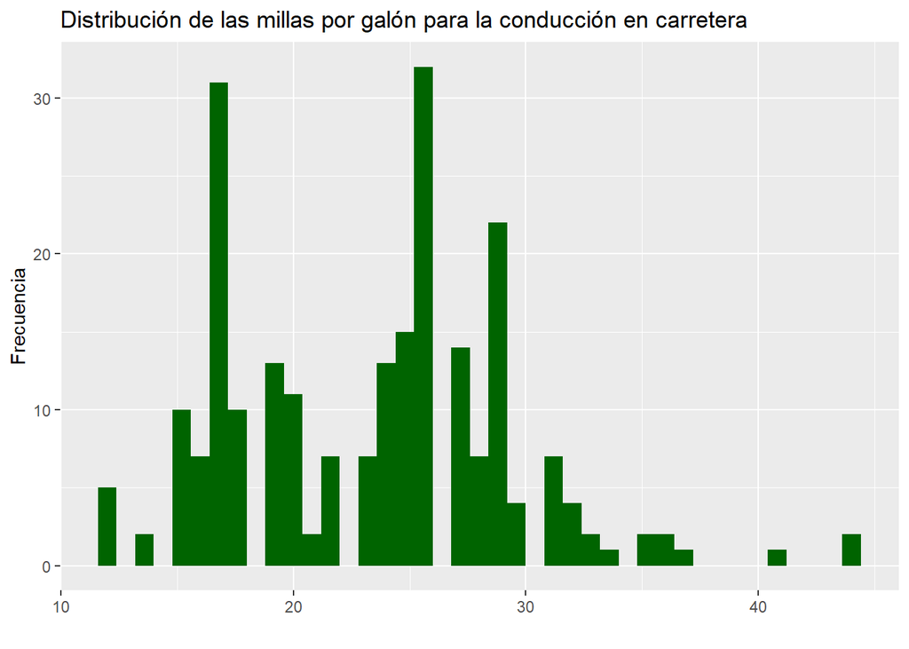

```r
ggplot(mpg, aes(hwy)) +
  geom_histogram(fill = "darkgreen", bins = 30, binwidth = 0.8) +
  ggtitle("Distribución de las millas por galón para la conducción en carretera") +
  xlab("") +
  ylab("Frecuencia")
```

## 4.2.- geom_x() colectivos

Los geom_x() colectivos se refeiere al hecho de superponer varios gráficos. Vamos a aprovechar para ver el geom_boxplot() y geom_violin().

El gráfico de violines muestra la distribución de los datos para una variable concreta. Este gráfico es similar al boxplot.

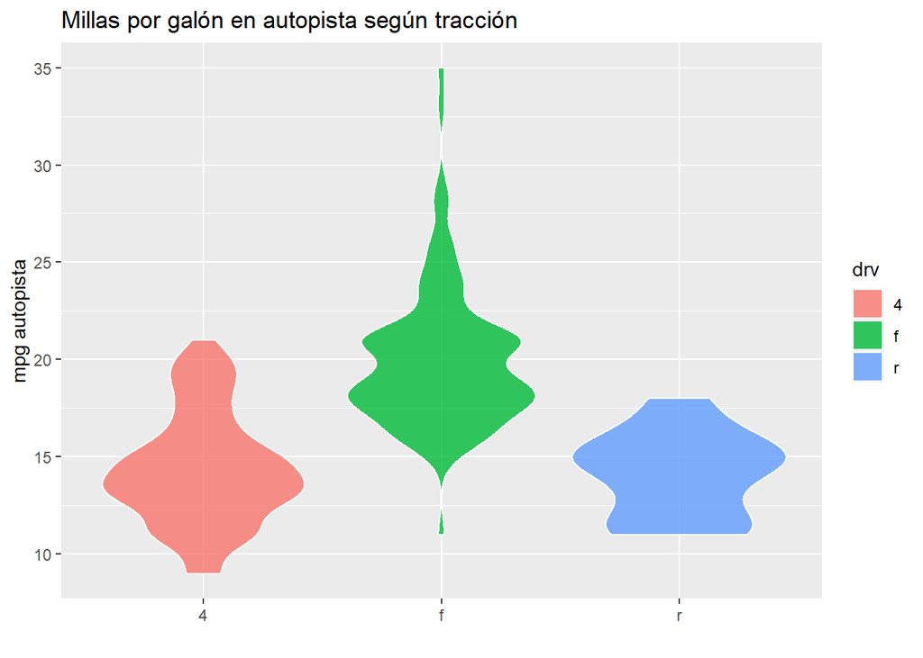

```r
ggplot(mpg, aes(x = drv, y = cty)) +
  geom_violin(aes(fill = drv), color = "white", alpha = 0.8) + #alpha=traslucido de la figura. Entre 0 y 1, 1 el color completo, 0 traslucido
  xlab("") +
  ylab("mpg autopista") +
  ggtitle("Millas por galón en autopista según tracción")
```

Hacemos el boxplot, ahora, para comparar:

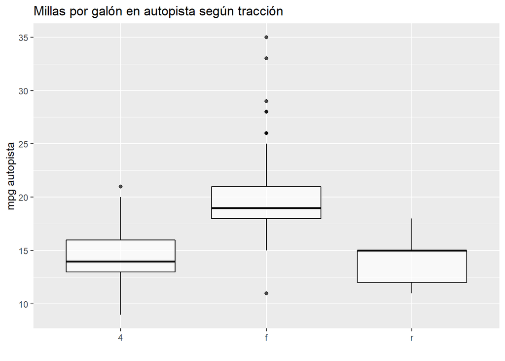

```r
ggplot(mpg, aes(x = drv, y = cty)) +
  geom_boxplot(color = "black", alpha = 0.7) +
  xlab("") +
  ylab("mpg autopista") +
  ggtitle("Millas por galón en autopista según tracción")
```

Para hacer una comparación efectiva superponemos ambos gráficos:

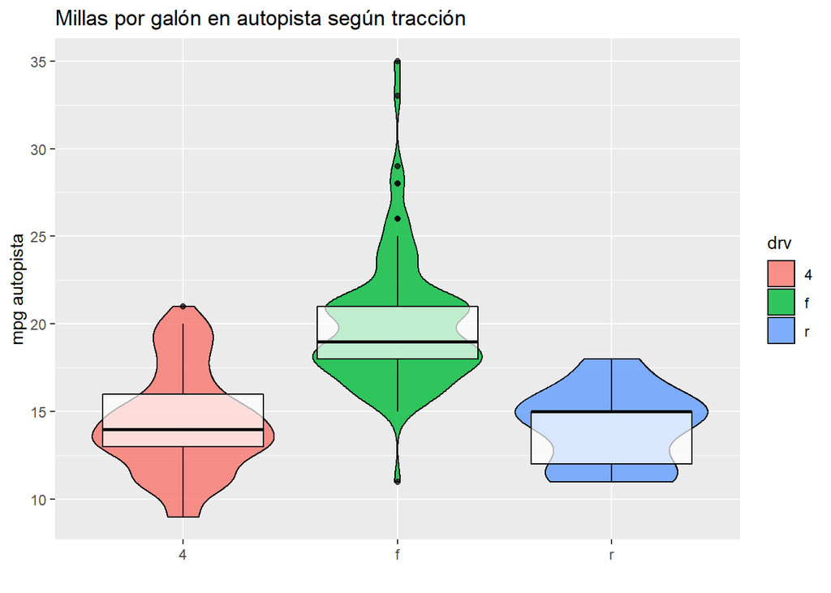

```r
ggplot(mpg, aes(x = drv, y = cty)) +
  geom_violin(aes(fill = drv), color = "black", alpha = 0.8) +
  geom_boxplot(color = "black", alpha = 0.7) +
  xlab("") +
  ylab("mpg autopista") +
  ggtitle("Millas por galón en autopista según tracción")
```

## 4.3.- facet_wrap() y facet_grip()

Estos parámetros permiten representar la información, en vez de en un único gráfico, en varios. La función **facet_wrap()** nos permite romper el grid en tantos como categorías queremos representar. En este caso queremos representar “class” que cuenta con 7 categorías, por tanto, obtendremos un grid de 3x3.

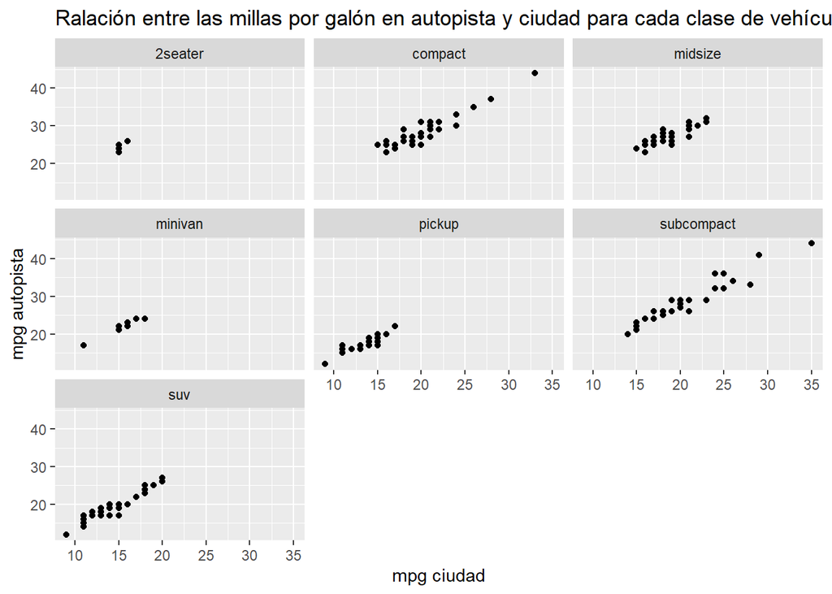

```r
ggplot(mpg, aes(x = cty, y = hwy)) +
  geom_point() +
  xlab("mpg ciudad") +
  ylab("mpg autopista") +
  ggtitle("Ralación entre las millas por galón en autopista y ciudad para cada clase de vehículo") +
  facet_wrap(.~class)
```

Si al gráfico anterior, le queremos meter colores para identificar el fabricante, simplemente añadimos a la función aes() el color en base a las categorías de la variable “manufacturer”.

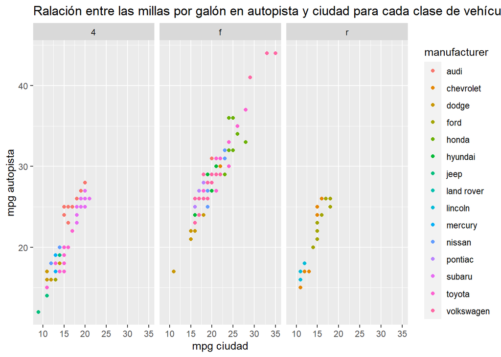

```r
ggplot(mpg, aes(x = cty, y = hwy, col = manufacturer)) +
  geom_point() +
  xlab("mpg ciudad") +
  ylab("mpg autopista") +
  ggtitle("Ralación entre las millas por galón en autopista y ciudad para cada clase de vehículo") +
  facet_wrap(.~drv)
```

El parámetro **facet_grid()** nos permite meter una expresión de tipo formula y con ello podemos dividir el grid en base a dos variables, por ejemplo, clase y tracción (drv):

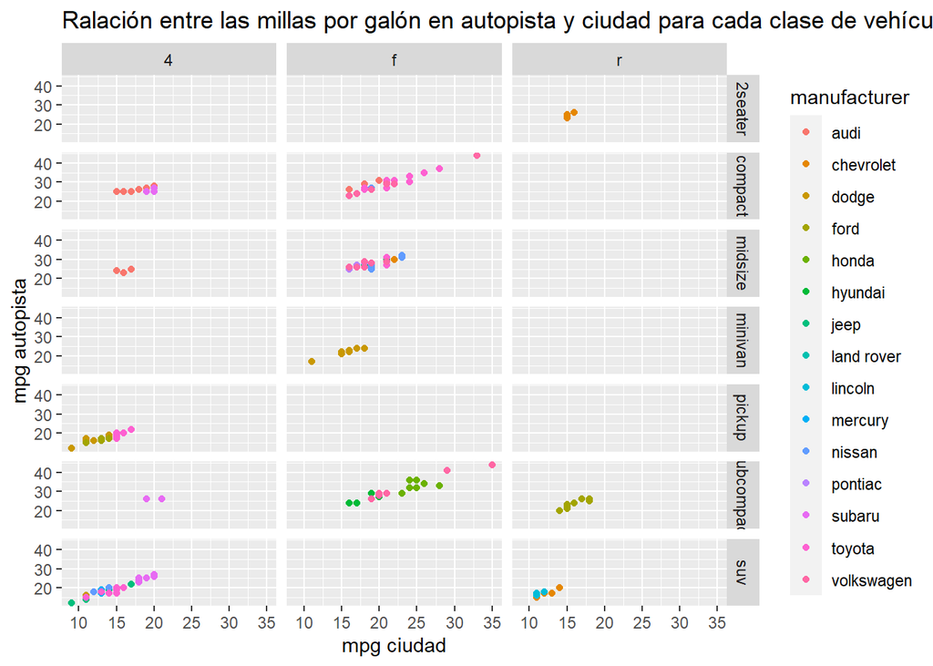

```r
ggplot(mpg, aes(x = cty, y = hwy, col = manufacturer)) +
  geom_point() +
  xlab("mpg ciudad") +
  ylab("mpg autopista") +
  ggtitle("Ralación entre las millas por galón en autopista y ciudad para cada clase de vehículo") +
  facet_grid(class~drv)
```

## 4.4.- Escalas de colores y leyendas

### 4.4.1.- Escalas de color discretas

Vamos a graficar cuántos modelos hay de cada cilindrada.

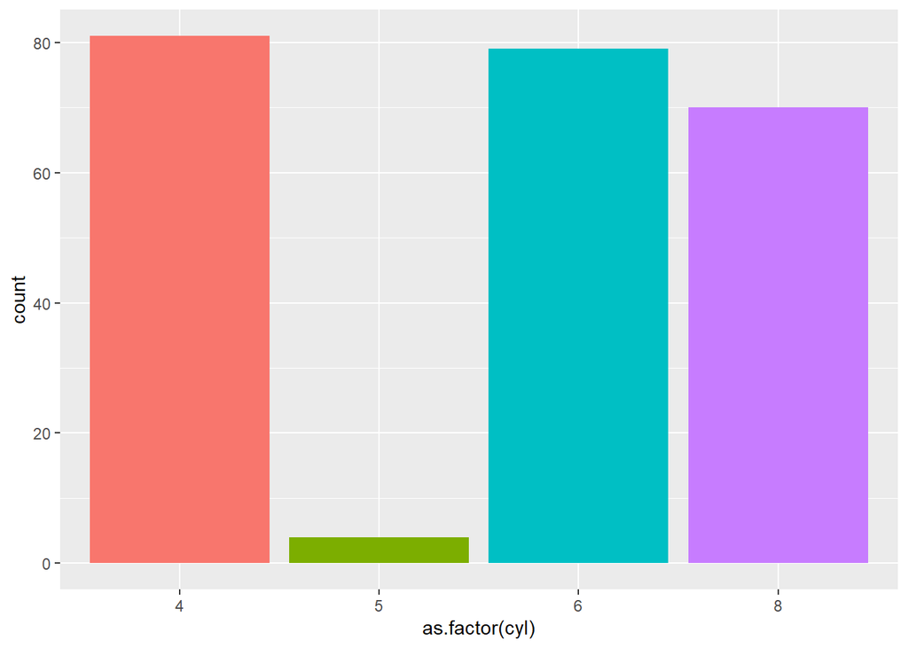

```r
fig = ggplot(mpg, aes(as.factor(cyl), fill = as.factor(cyl))) +
  geom_bar() +
  theme(legend.position = "none")

fig
```

Los modelos de 4 cilindradas son los más comunes frente a los modelos de 5 que son los menos comunes.

La escala predeterminada para colores discretos es **scale_fill_discrete()** que, a su vez, tiene como valor predeterminado **scale_fill_hue()**, por lo que estos son gráficos idénticos:

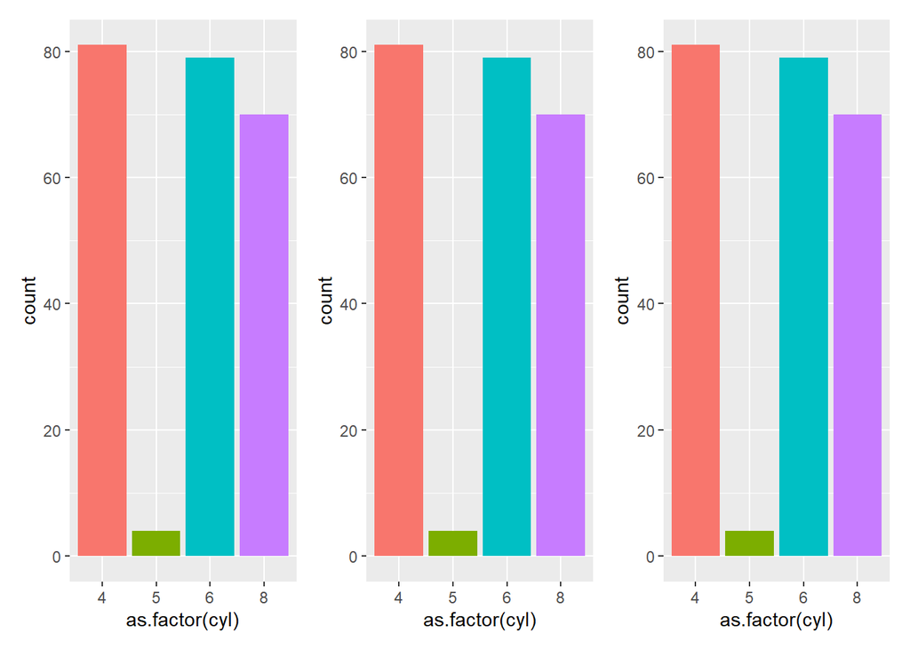

```r
fig +

fig + scale_fill_discrete() +

fig + scale_fill_hue()
```

**scale_colour_brewer()** es una escala de colores discreta. La gama de colores puede verse en:

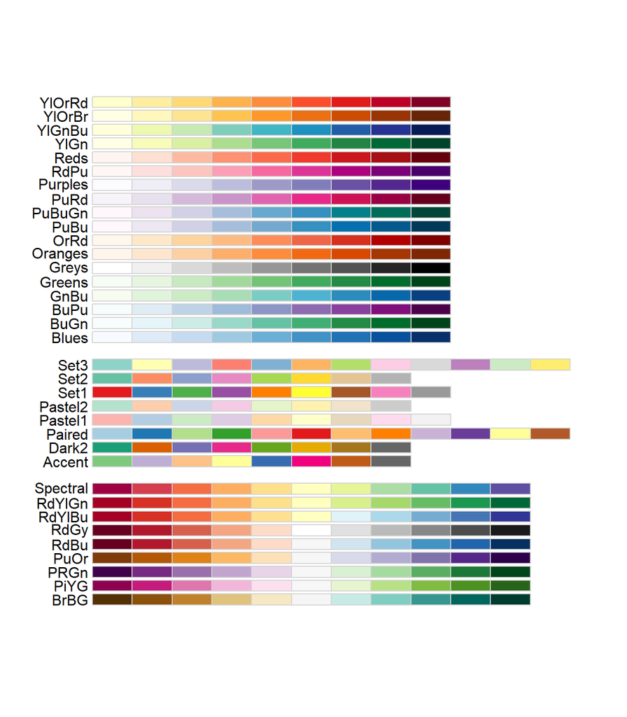

```r
RColorBrewer::display.brewer.all()
```

Aplicamos algunas de estas paletas a nuestro gráfico

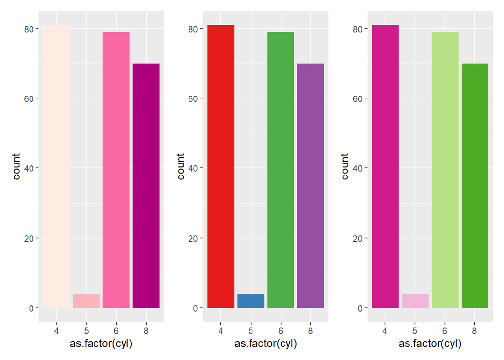

```r
fig + scale_fill_brewer(palette = "RdPu") +

fig + scale_fill_brewer(palette = "Set1") +

fig + scale_fill_brewer(palette = "PiYG")
```

También podemos realizar una escala manual, **scale_fill_manual()** de colores:

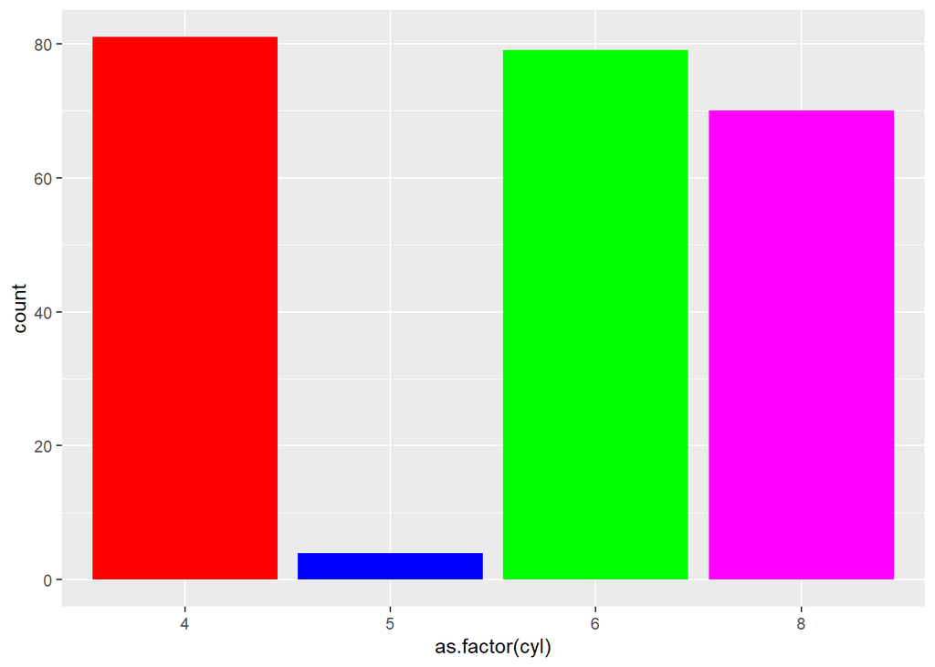

```r
fig + scale_fill_manual(values = c("red", "blue", "green", "magenta"))
```

### 4.4.2.- Escalas de color continuas

**scale_fill_continuous()** permite crear un paleta de colores continua:

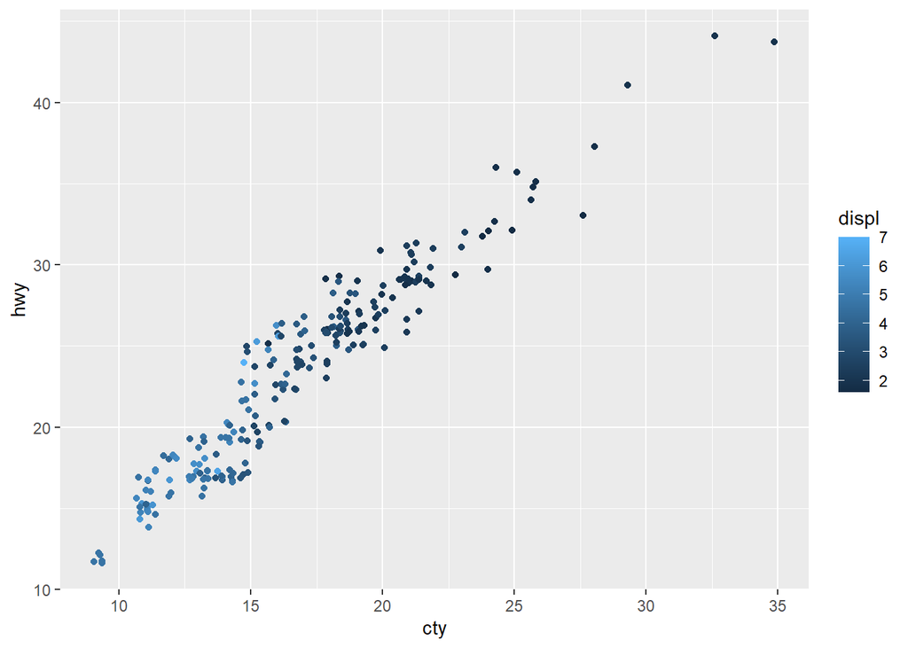

```r
ggplot(mpg, aes(cty, hwy, color = displ)) +
  geom_jitter() +
  scale_fill_continuous(breaks = NULL)
```

Para aprender más sobre escalas continuas véase: https://ggplot2-book.org/scale-colour.html

### 4.4.3.- Leyendas

Las leyendas se controlan bajo el parámetro **theme()**. Veamos primero aquellos relacionados con la posición de la leyenda: ‘legend.position’

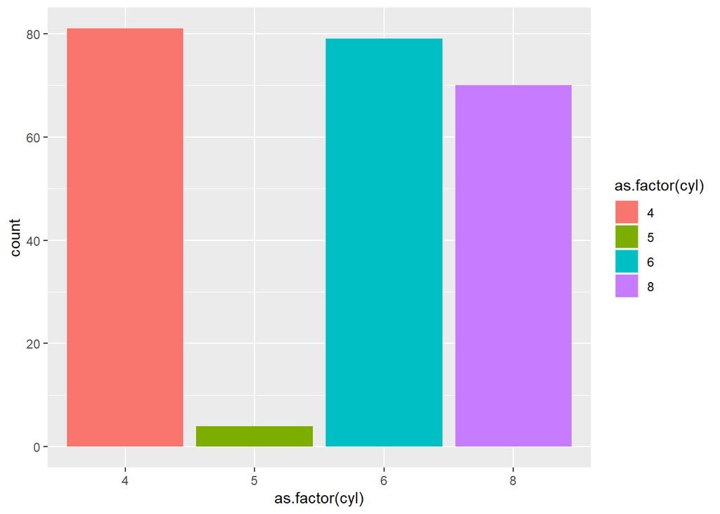

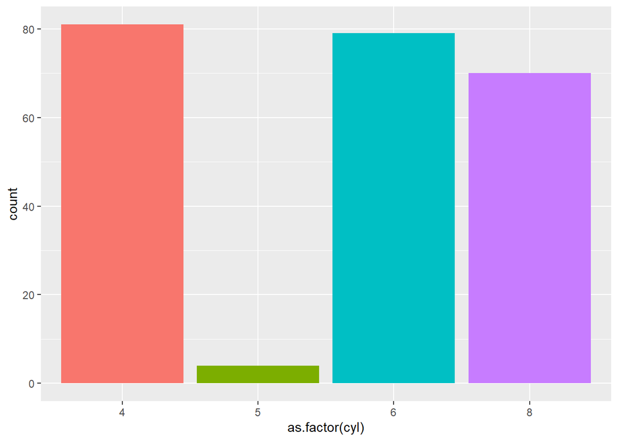

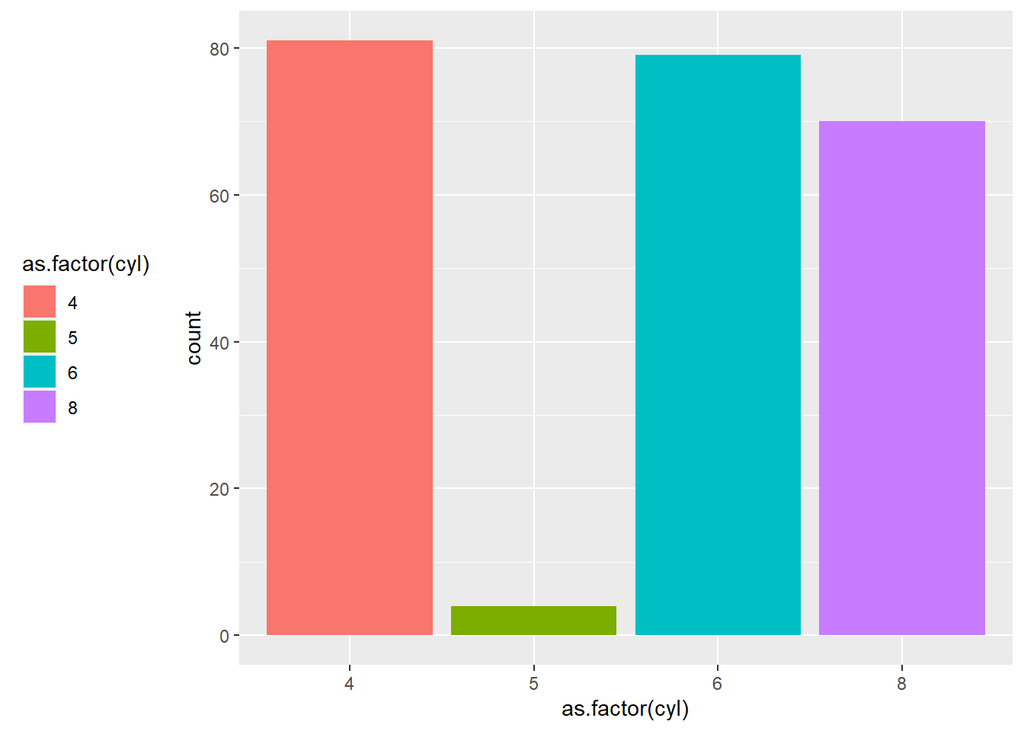

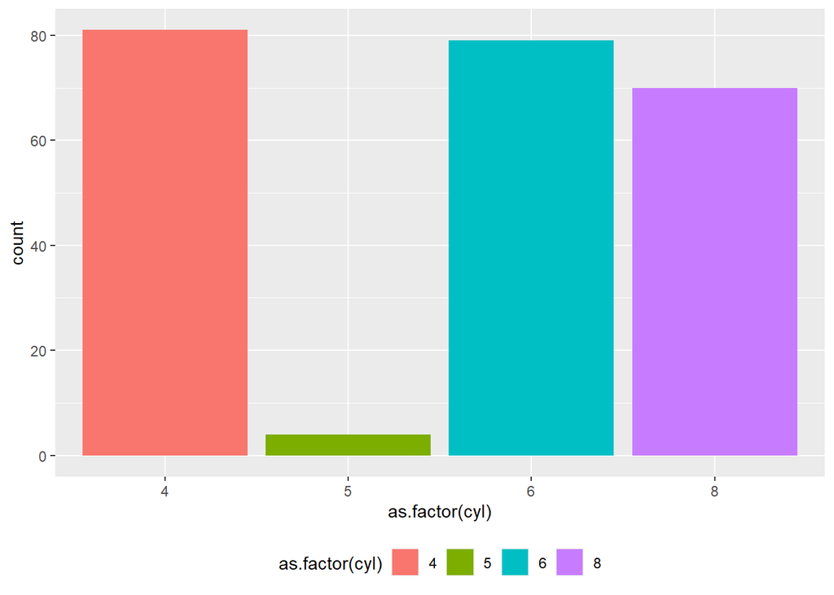

```r
l1 = ggplot(mpg, aes(as.factor(cyl), fill = as.factor(cyl))) +
  geom_bar()

l1 # Por defecto a la derecha

l1 + theme(legend.position = "none")

l1 + theme(legend.position = "left")

l1 + theme(legend.position = "bottom")
```

También, podemos insertar la leyenda dentro del propio gráfico si tuviésemos espacio (lo veremos en la sección 4.5.3).

## 4.5.- Temas

Supongamos que se quiere probar que existe una relación entre el consumo de combustible en ciudad y autopista y la cilindrada del motor. Para ello, se observa la relación entre el consumo de combustible de ciudad y carretera y se pinta según cilindrada. En este caso utilizamos **geom_jitter()** que es lo mismo que **geom_point(position = “jitter”)** ya que genera una pequeña cantidad de puntos respecto a la localización de cada punto de forma aleatoria y en muestras pequeñas resulta muy útil. **geom_abline()** agrega otra capa al gráfico, en este caso una recta y = x.

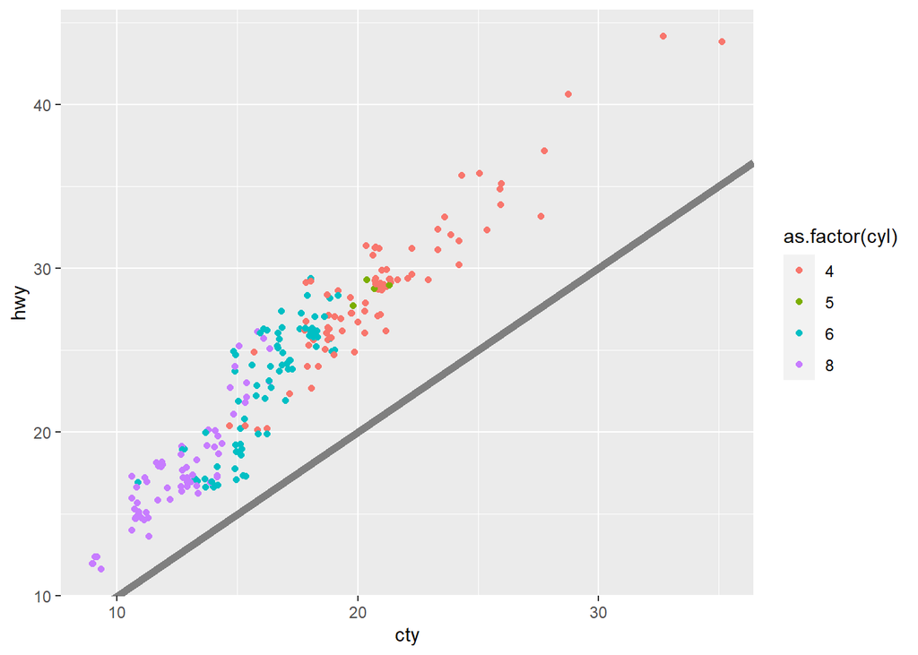

```r
g1 = ggplot(mpg, aes(cty, hwy, color = as.factor(cyl))) +
  #geom_point() +
  geom_jitter() +
  geom_abline(colour = "grey50", size = 2) +
  geom_abline(colour = "grey50", size = 2)

g1
```

Se observa que hay una alta relación entre el consumo en ciudad y autopista ya que los puntos están muy próximos a la recta donde los valores son x = y. Además, los altos consumos se asocian a mayor cilindrada y los consumos más bajos a cilindradas menores.

Ahora, para transformar el aspecto de este gráfico utilizaremos los parámetro labs(), theme() y theme_x().

### 4.5.1.- labs()

Este parámetro nos permite cambiar el título del gráfico, el nombre de los ejes y el título de la leyenda. Este parámetro sustituye al trío ggtitle() + xlab() + ylab():

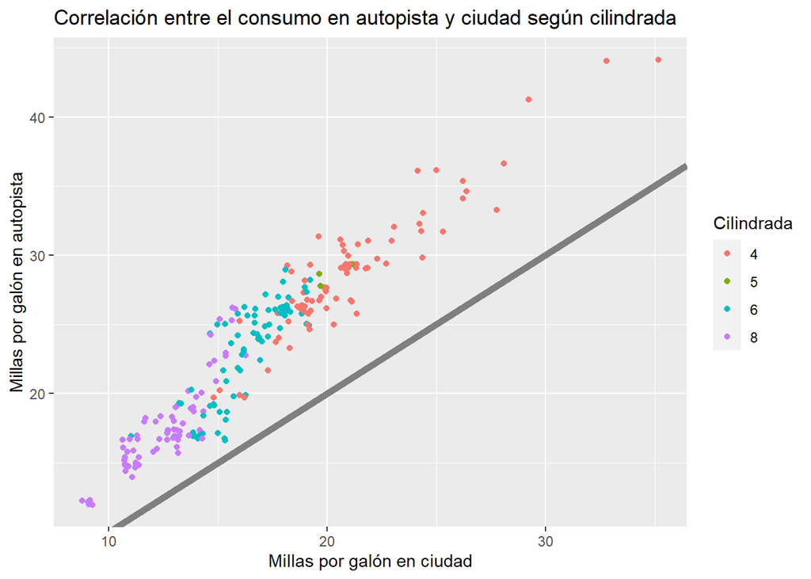

```r
g2 = g1 +
  labs(
    x = "Millas por galón en ciudad",
    y = "Millas por galón en autopista",
    colour = "Cilindrada",
    title = "Correlación entre el consumo en autopista y ciudad según cilindrada"
  )

g2
```

### 4.5.2.- theme_x()

R tiene varios temas propios, aunque existe la posibilidad de hacerlo al gusto. Nosotros vamos a elegir uno predeterminado para el ejemplo. En la siguiente imagen se muestran algunos ejemplos:

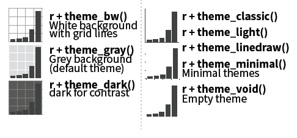

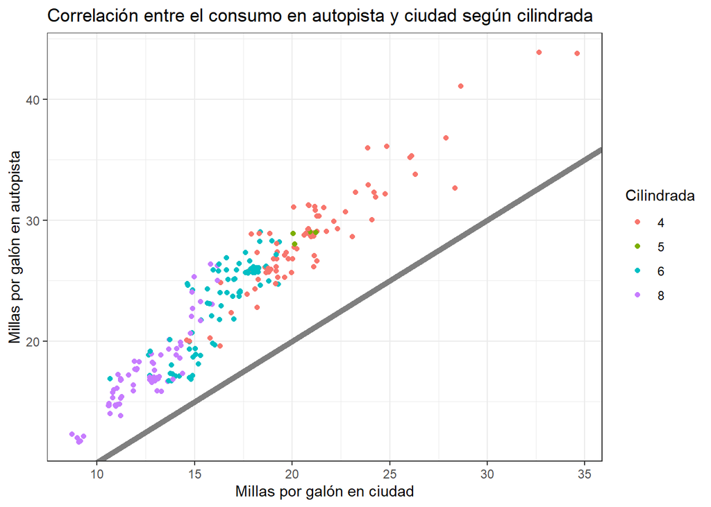

```r
g3 = g2 + theme_bw()

g3
```

### 4.5.3.- theme()

Supongamos que queremos presentar este gráfico en alguna revista donde exigen las siguientes características de diseño:

- La leyenda debe colocarse dentro del gráfico si hay espacio.
- El título del gráfico debe tener 13 puntos en negrita.
- Las líneas de cuadrícula principal deben ser de color gris pálido y las líneas de cuadrícula menor deben eliminarse.

Entonces utilizaremos la función theme() con los siguientes parámetros:

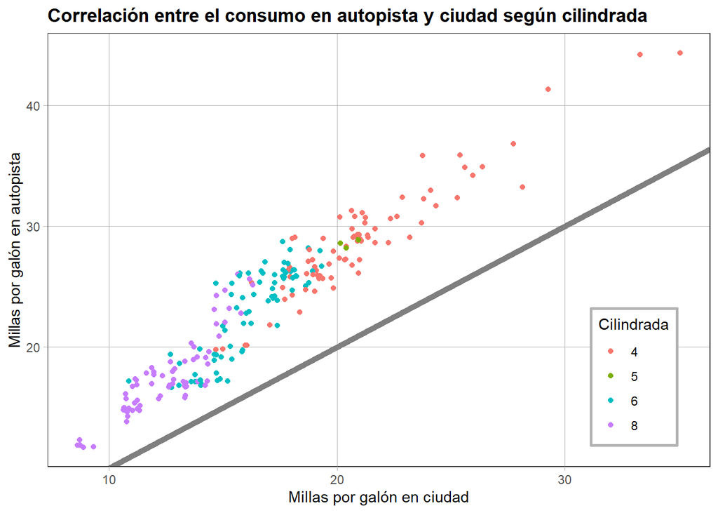

```r
g3 +
  theme(
    plot.title = element_text(face = "bold", size = 13),
    legend.background = element_rect(fill = "white", size = 1, colour = "grey70"),
    legend.justification = c(1, 0),
    legend.position = c(0.95, 0.05),
    axis.ticks = element_line(colour = "grey70", size = 0.2),
    panel.grid.major = element_line(colour = "grey70", size = 0.2),
    panel.grid.minor = element_blank()
  )
```

# 5.- Organizando gráficos

Otra opción que encontramos es la disposición de varios gráficos independientes en una única salida gracias a la librería **patchwork**. Para ello, realizaremos 4 gráficos y los juntaremos en 1:

```r
p1 = ggplot(mpg) +
  geom_point(aes(x = displ, y = hwy))

p2 = ggplot(mpg) +
  geom_bar(aes(x = as.character(year), fill = drv), position = "dodge") +
  labs(x = "year")

p3 = ggplot(mpg) +
  geom_density(aes(x = hwy, fill = drv), colour = NA) +
  facet_grid(drv~.)

p4 = ggplot(mpg) +
  stat_summary(aes(x = drv, y = hwy, fill = drv), geom = "col", fun.data = mean_se) +
  stat_summary(aes(x = drv, y = hwy), geom = "errorbar", fun.data = mean_se, width = 0.8)
```

Juntamos los gráficos:

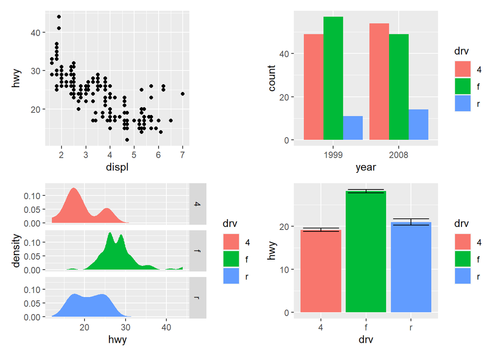

```r
p1 + p2 + p3 + p4
```

Como tenemos la misma variable en la leyenda (drv) podemos unificarla en una única leyenda con la función **plot_layout()** concretamente con el parámetro ‘guides’

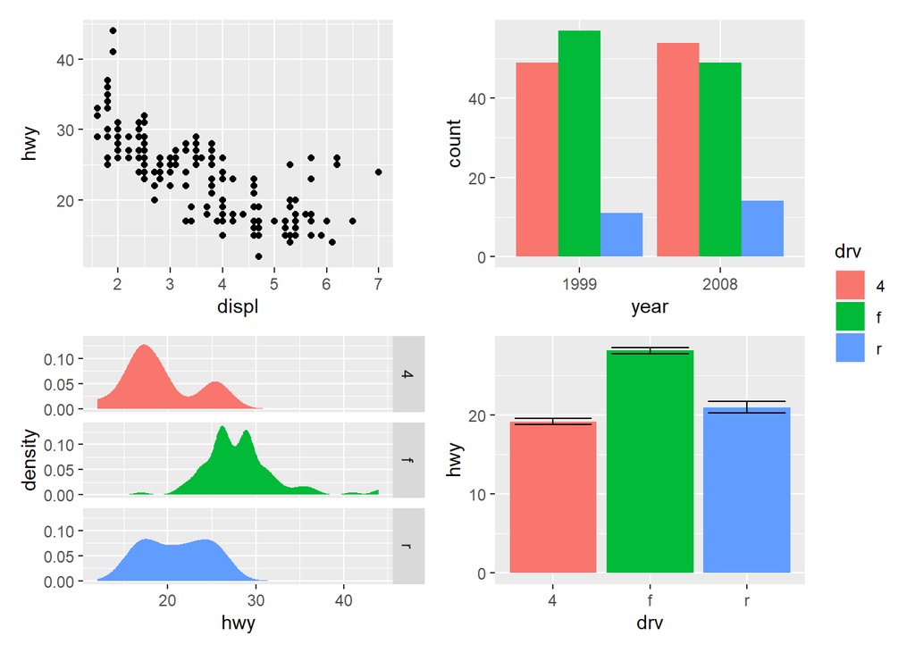

```r
p1 + p2 + p3 + p4 + plot_layout(guides = "collect")
```